# Import libraries and setup data

```python
import pandas as pd
import numpy as np
import pickle
import seaborn as sns
import matplotlib.pyplot as plt

%matplotlib inline
from pylab import rcParams

from sklearn.ensemble import RandomForestClassifier
from sklearn.ensemble import RandomForestRegressor
from sklearn.feature_selection import SelectFromModel
from sklearn.model_selection import train_test_split
from sklearn import preprocessing
from sklearn.preprocessing import StandardScaler
from sklearn.preprocessing import MinMaxScaler
from sklearn import utils
from scipy import stats

data = pd.read_csv("C:/Users/ndyla/Downloads/INFY Historical Data (1).csv")
columnsVar = ['Open', 'High', 'Low', 'Vol.', 'Change %']
```

```python
data = data[::-1]
data.head()
```

|  | Date | Price | Open | High | Low | Vol. | Change % |
| --- | --- | --- | --- | --- | --- | --- | --- |
| 3967 | 1/3/2005 | 131.43 | 131.4 | 148.7 | 129.94 | 9.10M | 1.33% |
| 3966 | 1/4/2005 | 129.6 | 131.77 | 131.77 | 128.98 | 10.22M | -1.39% |
| 3965 | 1/5/2005 | 127.28 | 128.05 | 128.98 | 124.09 | 22.20M | -1.79% |
| 3964 | 1/6/2005 | 126.73 | 126.58 | 129.85 | 123.9 | 27.03M | -0.43% |
| 3963 | 1/7/2005 | 127.17 | 126.19 | 128.05 | 123.71 | 33.50M | 0.35% |

```python
data.tail()
```

|  | Date | Price | Open | High | Low | Vol. | Change % |
| --- | --- | --- | --- | --- | --- | --- | --- |
| 4 | 12/24/2020 | 1,236.05 | 1,249.90 | 1,249.90 | 1,226.00 | 7.31M | -1.36% |
| 3 | 12/28/2020 | 1,240.30 | 1,238.45 | 1,248.00 | 1,236.00 | 4.61M | 0.34% |
| 2 | 12/29/2020 | 1,250.30 | 1,235.00 | 1,254.45 | 1,235.00 | 6.88M | 0.81% |
| 1 | 12/30/2020 | 1,246.80 | 1,253.00 | 1,253.30 | 1,238.15 | 5.19M | -0.28% |
| 0 | 12/31/2020 | 1,255.80 | 1,243.00 | 1,258.40 | 1,239.00 | 7.43M | 0.72% |

# Data cleaning

## Check for data types and removing the date out of the variable

Remove the date data out of the variable

```python
import datetime

def str_to_datetime1(s):
  split = s.split('/')
  month, day, year = int(split[0]), int(split[1]), int(split[2])
  return datetime.datetime(year=year, month=month, day=day)
```

```python
data['Date'] = data['Date'].apply(str_to_datetime1)
data['Date']
```

```
3967   2005-01-03
3966   2005-01-04
3965   2005-01-05
3964   2005-01-06
3963   2005-01-07
          ...
4      2020-12-24
3      2020-12-28
2      2020-12-29
1      2020-12-30
0      2020-12-31
Name: Date, Length: 3968, dtype: datetime64[ns]
```

```python
data.index = data.pop('Date')
data.index = data.index
data
```

| Date | Price | Open | High | Low | Vol. | Change % |
| --- | --- | --- | --- | --- | --- | --- |
| 2005-01-03 | 131.43 | 131.4 | 148.7 | 129.94 | 9.10M | 1.33% |
| 2005-01-04 | 129.6 | 131.77 | 131.77 | 128.98 | 10.22M | -1.39% |
| 2005-01-05 | 127.28 | 128.05 | 128.98 | 124.09 | 22.20M | -1.79% |
| 2005-01-06 | 126.73 | 126.58 | 129.85 | 123.9 | 27.03M | -0.43% |
| 2005-01-07 | 127.17 | 126.19 | 128.05 | 123.71 | 33.50M | 0.35% |
| ... | ... | ... | ... | ... | ... | ... |
| 2020-12-24 | 1,236.05 | 1,249.90 | 1,249.90 | 1,226.00 | 7.31M | -1.36% |
| 2020-12-28 | 1,240.30 | 1,238.45 | 1,248.00 | 1,236.00 | 4.61M | 0.34% |
| 2020-12-29 | 1,250.30 | 1,235.00 | 1,254.45 | 1,235.00 | 6.88M | 0.81% |
| 2020-12-30 | 1,246.80 | 1,253.00 | 1,253.30 | 1,238.15 | 5.19M | -0.28% |
| 2020-12-31 | 1,255.80 | 1,243.00 | 1,258.40 | 1,239.00 | 7.43M | 0.72% |

3968 rows × 6 columns

Check the data types with the line "data.dtypes"

```python
data.dtypes
```

```
Price       object
Open        object
High        object
Low         object
Vol.        object
Change %    object
dtype: object
```

Convert everything to float

```python
data["Price"] = data["Price"].str.replace(",", "")
data["Open"] = data["Open"].str.replace(",", "")
data["High"] = data["High"].str.replace(",", "")
data["Low"] = data["Low"].str.replace(",", "")
data["Vol."] = data["Vol."].str.replace("M", "")
data["Change %"] = data["Change %"].str.replace("%", "")
```

```python
data['Price'] = pd.to_numeric(data['Price'], errors='coerce')
data['Open'] = pd.to_numeric(data['Open'], errors='coerce')
data['High'] = pd.to_numeric(data['High'], errors='coerce')
data['Low'] = pd.to_numeric(data['Low'], errors='coerce')
data['Vol.'] = pd.to_numeric(data['Vol.'], errors='coerce')
data['Change %'] = pd.to_numeric(data['Change %'], errors='coerce')
```

Check the data types by using the line "data.dtypes" again and confirm it is changed to float64

```python
data.dtypes
```

```
Price       float64
Open        float64
High        float64
Low         float64
Vol.        float64
Change %    float64
dtype: object
```

## Check the shape (length and width) of ori_data

```python
data.shape
```

```
(3968, 6)
```

## Checking for null data

```python
data.isna().sum()
```

```
Price        0
Open         0
High         0
Low          0
Vol.        19
Change %     0
dtype: int64
```

As we can see, this dataset has a total of 19 null data in the "Vol." column

```python
data[data.isna().any(axis=1)]
```

| Date | Price | Open | High | Low | Vol. | Change % |
| --- | --- | --- | --- | --- | --- | --- |
| 2006-06-25 | 185.39 | 185.72 | 187.27 | 184.79 | NaN | -0.06 |
| 2006-10-21 | 257.19 | 260.44 | 262.92 | 256.72 | NaN | 0.47 |
| 2009-05-18 | 223.25 | 211.45 | 236.99 | 208.48 | NaN | 13.02 |
| 2009-10-17 | 272.02 | 273.46 | 274.56 | 270.04 | NaN | 0.15 |
| 2010-02-06 | 295.10 | 292.81 | 296.23 | 292.55 | NaN | 1.14 |
| 2010-11-05 | 382.18 | 382.47 | 383.47 | 380.85 | NaN | 0.14 |
| 2012-01-07 | 351.62 | 352.08 | 353.64 | 350.73 | NaN | 0.11 |
| 2012-03-03 | 354.46 | 353.06 | 355.86 | 353.06 | NaN | 0.44 |
| 2012-04-28 | 297.13 | 297.37 | 298.18 | 296.05 | NaN | 0.20 |
| 2012-09-08 | 309.55 | 307.22 | 310.04 | 307.22 | NaN | 0.35 |
| 2012-11-13 | 289.99 | 291.94 | 292.69 | 289.34 | NaN | -0.88 |
| 2013-05-11 | 292.93 | 292.70 | 293.93 | 291.58 | NaN | -0.40 |
| 2013-11-03 | 406.71 | 406.78 | 408.74 | 405.94 | NaN | 0.08 |
| 2014-03-22 | 408.77 | 408.52 | 410.98 | 406.93 | NaN | -0.29 |
| 2014-10-23 | 471.90 | 471.88 | 472.94 | 470.92 | NaN | 0.24 |
| 2015-11-11 | 549.46 | 554.62 | 554.62 | 547.17 | NaN | 0.34 |
| 2016-10-30 | 497.12 | 496.57 | 499.03 | 495.98 | NaN | 0.46 |
| 2018-11-07 | 675.50 | 673.00 | 677.50 | 672.00 | NaN | 1.36 |
| 2019-10-27 | 648.85 | 648.85 | 648.85 | 648.85 | NaN | 1.79 |

```python
data = data.fillna(ori_data['Vol.'].mean())

import matplotlib.pyplot as plt
```

```python
data.isnull().sum()
```

```
Price       0
Open        0
High        0
Low         0
Vol.        0
Change %    0
dtype: int64
```

Each row shows zero, this means that no more null data inside

## Detecting Outliers

Here we will find out the Z-Score in order to determine which is the outliers.

```python
z = np.abs(stats.zscore(data))
z
```

| Date | Price | Open | High | Low | Vol. | Change % |
| --- | --- | --- | --- | --- | --- | --- |
| 2005-01-03 | 1.343799 | 1.344528 | 1.272027 | 1.340744 | 0.175757 | 0.646023 |
| 2005-01-04 | 1.352515 | 1.342765 | 1.351868 | 1.345361 | 0.040707 | 0.755527 |
| 2005-01-05 | 1.363566 | 1.360491 | 1.365025 | 1.368884 | 1.403840 | 0.961637 |
| 2005-01-06 | 1.366186 | 1.367496 | 1.360922 | 1.369798 | 1.986241 | 0.260862 |
| 2005-01-07 | 1.364090 | 1.369354 | 1.369411 | 1.370711 | 2.766393 | 0.141053 |
| ... | ... | ... | ... | ... | ... | ... |
| 2020-12-24 | 3.917722 | 3.985070 | 3.921162 | 3.931595 | 0.391595 | 0.740069 |
| 2020-12-28 | 3.937966 | 3.930511 | 3.912202 | 3.979697 | 0.717160 | 0.135900 |
| 2020-12-29 | 3.985597 | 3.914072 | 3.942619 | 3.974887 | 0.443444 | 0.378080 |
| 2020-12-30 | 3.968926 | 3.999841 | 3.937196 | 3.990039 | 0.647224 | 0.183571 |
| 2020-12-31 | 4.011795 | 3.952192 | 3.961247 | 3.994128 | 0.377125 | 0.331705 |

3968 rows × 6 columns

For our eyes, it is difficult to see which one is the outliers as right now it just looks like random numbers are displayed to us. A value will be called outlier if it's Z-Score is more than 3.

Checking the sum of outliers from each column

```python
(np.abs(stats.zscore(data)) > 3).sum()
```

```
Price       61
Open        60
High        61
Low         59
Vol.        53
Change %    60
dtype: int64
```

Checking the size/shape of data after the trimming of outliers

```python
data_clean = data[((np.abs(stats.zscore(data)))<3).all(axis=1)]
data_clean
```

| Date | Price | Open | High | Low | Vol. | Change % |
| --- | --- | --- | --- | --- | --- | --- |
| 2005-01-03 | 131.43 | 131.40 | 148.70 | 129.94 | 9.10 | 1.33 |
| 2005-01-04 | 129.60 | 131.77 | 131.77 | 128.98 | 10.22 | -1.39 |
| 2005-01-05 | 127.28 | 128.05 | 128.98 | 124.09 | 22.20 | -1.79 |
| 2005-01-06 | 126.73 | 126.58 | 129.85 | 123.90 | 27.03 | -0.43 |
| 2005-01-07 | 127.17 | 126.19 | 128.05 | 123.71 | 33.50 | 0.35 |
| ... | ... | ... | ... | ... | ... | ... |
| 2020-09-25 | 1011.45 | 975.80 | 1014.90 | 975.00 | 13.31 | 3.70 |
| 2020-09-28 | 1010.40 | 1014.80 | 1016.15 | 998.50 | 8.55 | -0.10 |
| 2020-09-29 | 1009.00 | 1018.00 | 1028.00 | 1004.10 | 8.71 | -0.14 |
| 2020-09-30 | 1008.25 | 1009.00 | 1023.95 | 1005.00 | 8.05 | -0.07 |
| 2020-10-01 | 1017.65 | 1020.60 | 1026.50 | 1011.75 | 5.56 | 0.93 |

3819 rows × 6 columns

```python
data_clean.shape
```

```
(3819, 6)
```

```python
# data = data_clean
```

## Using the MinMaxScaler from sklearn to do Normalization

```python
# data
```

#### First, we normalize the training set (use fit_transform)

```python
# scaler = MinMaxScaler(feature_range = (0, 1))
# scaled_data = pd.DataFrame(scaler.fit_transform(data), columns = data.columns)
# scaled_data
```

## Random Forest Algorithm to do Feature Selection

### Random Forest Regressor to get feature importance

```python
rf=RandomForestRegressor(n_estimators = 100, random_state=42)
rf.fit(data.drop('Price', axis=1).astype('int'), data.Price.astype('int'))
rf.feature_importances_
```

```
array([1.84677917e-02, 6.07805371e-01, 3.73619044e-01, 3.34161239e-05,
       7.43764849e-05])
```

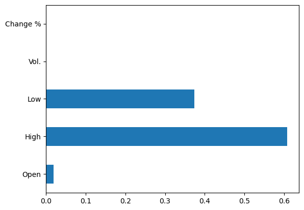

```python
(pd.Series(rf.feature_importances_, index=data.drop('Price', axis=1).columns).plot(kind='barh'))
```

### Random Forest Classifier with SelectFromModel to get the name of the features selected

```python
sel = SelectFromModel(RandomForestClassifier(n_estimators = 100,random_state=42))
sel.fit(data.drop('Price', axis=1).astype(int), data.Price.astype(int))
selected_feat= data.drop('Price', axis=1).columns[(sel.get_support())]
print(selected_feat)
```

```
Index(['Open', 'High', 'Low'], dtype='object')
```

```python
variable = 'High'
```

```python
data = data[[variable,'Price']]
data
```

| Date | High | Price |
| --- | --- | --- |
| 2005-01-03 | 148.70 | 131.43 |
| 2005-01-04 | 131.77 | 129.60 |
| 2005-01-05 | 128.98 | 127.28 |
| 2005-01-06 | 129.85 | 126.73 |
| 2005-01-07 | 128.05 | 127.17 |
| ... | ... | ... |
| 2020-12-24 | 1249.90 | 1236.05 |
| 2020-12-28 | 1248.00 | 1240.30 |
| 2020-12-29 | 1254.45 | 1250.30 |
| 2020-12-30 | 1253.30 | 1246.80 |
| 2020-12-31 | 1258.40 | 1255.80 |

3968 rows × 2 columns

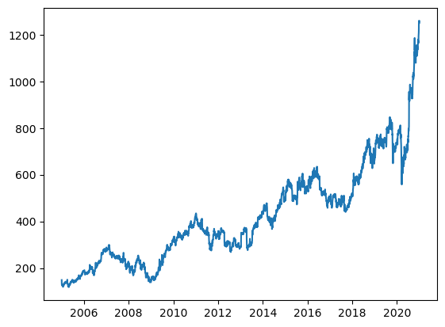

```python
plt.plot(data.index, data[variable])
```

```python
data
```

| Date | High | Price |
| --- | --- | --- |
| 2005-01-03 | 148.70 | 131.43 |
| 2005-01-04 | 131.77 | 129.60 |
| 2005-01-05 | 128.98 | 127.28 |
| 2005-01-06 | 129.85 | 126.73 |
| 2005-01-07 | 128.05 | 127.17 |
| ... | ... | ... |
| 2020-12-24 | 1249.90 | 1236.05 |
| 2020-12-28 | 1248.00 | 1240.30 |
| 2020-12-29 | 1254.45 | 1250.30 |
| 2020-12-30 | 1253.30 | 1246.80 |
| 2020-12-31 | 1258.40 | 1255.80 |

3968 rows × 2 columns

```python
df = data
df
```

| Date | High | Price |
| --- | --- | --- |
| 2005-01-03 | 148.70 | 131.43 |
| 2005-01-04 | 131.77 | 129.60 |
| 2005-01-05 | 128.98 | 127.28 |
| 2005-01-06 | 129.85 | 126.73 |
| 2005-01-07 | 128.05 | 127.17 |
| ... | ... | ... |
| 2020-12-24 | 1249.90 | 1236.05 |
| 2020-12-28 | 1248.00 | 1240.30 |
| 2020-12-29 | 1254.45 | 1250.30 |
| 2020-12-30 | 1253.30 | 1246.80 |
| 2020-12-31 | 1258.40 | 1255.80 |

3968 rows × 2 columns

```python
def str_to_datetime(s):
  split = s.split('-')
  year, month, day = int(split[0]), int(split[1]), int(split[2])
  return datetime.datetime(year=year, month=month, day=day)
```

```python
def data_to_windowed_data(dataframe, first_date_str, last_date_str, n=3):
  first_date = str_to_datetime(first_date_str)
  last_date  = str_to_datetime(last_date_str)

  target_date = first_date

  dates = []
  X, Y, Z = [], [], []

  last_time = False
  while True:
    data_subset = dataframe.loc[:target_date].tail(3+1)

    if len(data_subset) != n+1:
      print(f'Error: Window of size {n} is too large for date {target_date}')
      return

    values = data_subset[variable].to_numpy()
    price = data_subset['Price'].to_numpy()
    x, y, z = values[:-1], values[-1], price[-1]

    if target_date in dataframe.index:
        dates.append(target_date)
        X.append(x)
        Y.append(y)
        Z.append(z)

    next_week = data.loc[target_date:target_date+datetime.timedelta(days=7)]
    next_datetime_str = str(next_week.head(2).tail(1).index.values[0])
    next_date_str = next_datetime_str.split('T')[0]
    year_month_day = next_date_str.split('-')
    year, month, day = year_month_day
    next_date = datetime.datetime(day=int(day), month=int(month), year=int(year))

    if last_time:
      break

    target_date = next_date

    if target_date == last_date:
      last_time = True

  ret_data = pd.DataFrame({})
  ret_data['Target Date'] = dates

  X = np.array(X)
  for i in range(0, n):
    X[:, i]
    ret_data[f'High-{n-i}'] = X[:, i]

  ret_data[variable] = Y
  ret_data['Price'] = Z
  return ret_data

start_date = '2005-1-7'
finish_date = '2015-12-31'
windowed_data = data_to_windowed_data(data_clean,
                                start_date,
                                finish_date,
                                n=3)
windowed_data
```

|  | Target Date | High-3 | High-2 | High-1 | High | Price |
| --- | --- | --- | --- | --- | --- | --- |
| 0 | 2005-01-07 | 131.77 | 128.98 | 129.85 | 128.05 | 127.17 |
| 1 | 2005-01-10 | 128.98 | 129.85 | 128.05 | 130.22 | 123.70 |
| 2 | 2005-01-11 | 129.85 | 128.05 | 130.22 | 125.43 | 122.26 |
| 3 | 2005-01-13 | 128.05 | 130.22 | 125.43 | 127.12 | 122.06 |
| 4 | 2005-01-14 | 130.22 | 125.43 | 127.12 | 124.53 | 122.41 |
| ... | ... | ... | ... | ... | ... | ... |
| 2658 | 2015-12-24 | 549.36 | 544.42 | 546.93 | 547.89 | 543.88 |
| 2659 | 2015-12-28 | 544.42 | 546.93 | 547.89 | 550.65 | 548.04 |
| 2660 | 2015-12-29 | 546.93 | 547.89 | 550.65 | 550.65 | 548.02 |
| 2661 | 2015-12-30 | 547.89 | 550.65 | 550.65 | 548.96 | 538.89 |
| 2662 | 2015-12-31 | 550.65 | 550.65 | 548.96 | 550.62 | 548.36 |

2663 rows × 6 columns

```python
def windowed_data_to_date_X_y(windowed_dataframe):
  data_as_np = windowed_data.to_numpy()

  dates = data_as_np[:, 0]

  middle_matrix = data_as_np[:, 1:-2]

  X = middle_matrix.reshape((len(dates), middle_matrix.shape[1], 1))

  Y = data_as_np[:, -1]

  high = data_as_np[:, -2]

  return dates, X.astype(np.float32), Y.astype(np.float32), high.astype(np.float32)

dates, X, y, high = windowed_data_to_date_X_y(windowed_data)

dates.shape, X.shape, y.shape
```

```
((2663,), (2663, 3, 1), (2663,))
```

```python
len(dates)
```

```
2663
```

```
(1597,)
```

[figure not shown]

```python
q_60 = int(len(dates) * .6)
q_80 = int(len(dates) * .8)

dates_train, X_train, y_train, h_train = dates[:q_60], X[:q_60], y[:q_60], high[:q_60]

dates_val, X_val, y_val, h_val = dates[q_60:q_80], X[q_60:q_80], y[q_60:q_80], high[q_60:q_80]
dates_test, X_test, y_test, h_test = dates[q_80:], X[q_80:], y[q_80:], high[q_80:]

plt.plot(dates_train, y_train)
# plt.plot(dates_train, h_train)

plt.plot(dates_val, y_val)
# plt.plot(dates_val, h_val)

plt.plot(dates_test, y_test)
# plt.plot(dates_test, h_test)


plt.legend(['Train (80%)', 'Validation (10%)', 'Test (10%)'])
q_60
y_train.shape
```

# Importing the TensorFlow library

#### We will import the TensorFlow library developed by Google Brain team. TensorFlow will act as a backend for Keras. Subsequently, import all the layers (Bidirectional, Dropout, Activation, Dense, LSTM)

Plan for the model: layers (LSTM, dense, bidirectional), random state, optimiser (adam, SGD, adagrad, adamax, nadam, adabound, RMSProp, adadelta), epochs, and batch size, activation (relu, linear, sigmoid, etc), dropout rate

```python
from tensorflow import keras

from tensorflow.keras.layers import Input, Bidirectional, Dropout, Activation, Dense, LSTM
```

In order to easily sequence all of these layers, we can import "Sequences"

```python
from tensorflow.keras.models import Sequential
```

```python
dropout_rate = 0.2
```

Now, lets start and make the model

```python
model = Sequential([Input((3,1)),
    LSTM(128,return_sequences=True),
    LSTM(128,return_sequences=False),
#     Dropout(dropout_rate),
    Dense(units=25, activation='linear'),
    Dense(units=1)
])
```

We will be using "Adam" optimiser. "Adam" is short for Adaptive Moment Estimation. It dynamically adapts the learning rate overtime during training. After that, lets see the summary of our model.

```python
# from keras.optimizers import SGD
# opt = SGD(learning_rate=0.1, momentum=0.9, nesterov=True)

from tensorflow.keras.optimizers import Adam
adamNew = Adam(learning_rate=0.00001)

from keras.optimizers import SGD
opt = SGD(learning_rate=0.0001)

model.compile(
    loss='mse',
    optimizer=adamNew,
    metrics=['mean_absolute_error']
)

model.summary()
```

```
Model: "sequential_2"
_________________________________________________________________
 Layer (type)                Output Shape              Param #
=================================================================
 lstm_4 (LSTM)               (None, 3, 128)            66560

 lstm_5 (LSTM)               (None, 128)               131584

 dense_4 (Dense)             (None, 25)                3225

 dense_5 (Dense)             (None, 1)                 26

=================================================================
Total params: 201,395
Trainable params: 201,395
Non-trainable params: 0
_________________________________________________________________
```

```python
history = model.fit(
    X_train,
    y_train,
    epochs=100,
    batch_size=1,
    shuffle=False
)
```

[figure not shown]

```python
plt.figure(figsize=(15, 6))
# plt.plot(history.history['loss'], label='loss', color='green')
plt.plot(history.history['mean_absolute_error'], label='mse', color='red')
plt.legend()
plt.show()
```

```python
from sklearn.metrics import mean_squared_error, mean_absolute_error, mean_absolute_percentage_error
```

```
MAPE: 7.695440948009491
MSE: 308.51053
MAE: 15.93251
RMSE: 17.564468
```

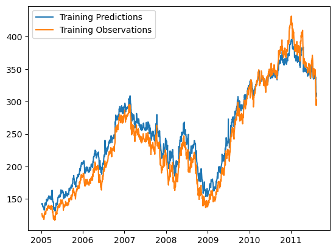

```python
train_predictions = model.predict(X_train).flatten()

plt.plot(dates_train, train_predictions)
plt.plot(dates_train, y_train)
plt.legend(['Training Predictions', 'Training Observations'])

mape = mean_absolute_percentage_error(y_train, train_predictions)*100
mse = mean_squared_error(y_train, train_predictions)
mae = mean_absolute_error(y_train, train_predictions)
rmse = np.sqrt(mse)

print("MAPE:", mape)
print("MSE:", mse)
print("MAE:", mae)
print("RMSE:", rmse)
```

```python
# ADD MAPE ALSO
```

```
MAPE: 2.9750576242804527
MSE: 136.08267
MAE: 9.463438
RMSE: 11.665448
```

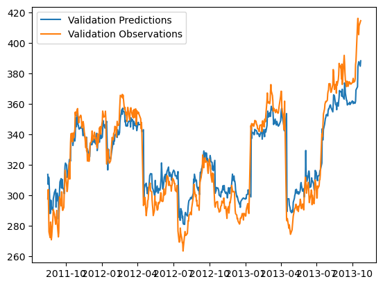

```python
val_predictions = model.predict(X_val).flatten()

plt.plot(dates_val, val_predictions)
plt.plot(dates_val, y_val)
plt.legend(['Validation Predictions', 'Validation Observations'])

mape = mean_absolute_percentage_error(y_val, val_predictions)*100
mse = mean_squared_error(y_val, val_predictions)
mae = mean_absolute_error(y_val, val_predictions)
rmse = np.sqrt(mse)

print("MAPE:", mape)
print("MSE:", mse)
print("MAE:", mae)
print("RMSE:", rmse)
```

```
MAPE: 15.258227288722992
MSE: 8141.9165
MAE: 77.860146
RMSE: 90.23257
```

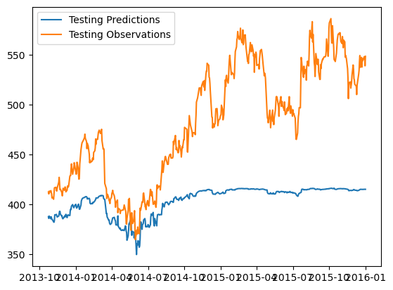

```python
test_predictions = model.predict(X_test).flatten()

plt.plot(dates_test, test_predictions)
plt.plot(dates_test, y_test)
plt.legend(['Testing Predictions', 'Testing Observations'])

mape = mean_absolute_percentage_error(y_test, test_predictions)*100
mse = mean_squared_error(y_test, test_predictions)
mae = mean_absolute_error(y_test, test_predictions)
rmse = np.sqrt(mse)

print("MAPE:", mape)
print("MSE:", mse)
print("MAE:", mae)
print("RMSE:", rmse)
```

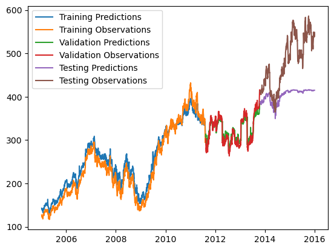

```python
plt.plot(dates_train, train_predictions)
plt.plot(dates_train, y_train)
plt.plot(dates_val, val_predictions)
plt.plot(dates_val, y_val)
plt.plot(dates_test, test_predictions)
plt.plot(dates_test, y_test)
# plt.plot(dates_test, h_test)
plt.legend(['Training Predictions',
            'Training Observations',
            'Validation Predictions',
            'Validation Observations',
            'Testing Predictions',
            'Testing Observations'])
```

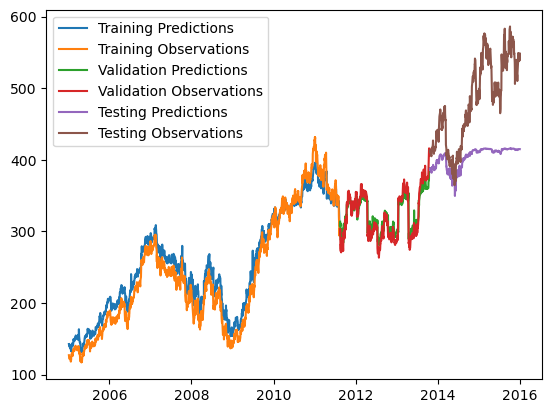

```python
plt.plot(dates_train, train_predictions)
plt.plot(dates_train, y_train)
plt.plot(dates_val, val_predictions)
plt.plot(dates_val, y_val)
plt.plot(dates_test, test_predictions)
plt.plot(dates_test, y_test)
plt.legend(['Training Predictions',
            'Training Observations',
            'Validation Predictions',
            'Validation Observations',
            'Testing Predictions',
            'Testing Observations'])
```